# Explore Time Series Analysis

This is an exploration of time series analysis that includes moving average, holt-winters smoothing, and ARIMA models.

loading libraries

```r
library(data.table)
library(dplyr)
library(TTR)
library(forecast)
```

Lets start with water usage data over time Read data from a csv and convert it to a time series. This is a randomly generated data for experimenting purposes.

```r
smc_test <- fread('smc_test.csv', stringsAsFactors = FALSE)
smc_test <- arrange(smc_test, usage_date,cust_loc_id)
smc <- smc_test %>%  group_by(usage_date) %>% summarise(usage_ccf = sum(usage_ccf)/1000)
smc_ts_matrix <- as.matrix(smc[2])
smc_timeseries <- ts(smc_ts_matrix, frequency=12, start=c(2014,1))
```

Plotting the timeseries

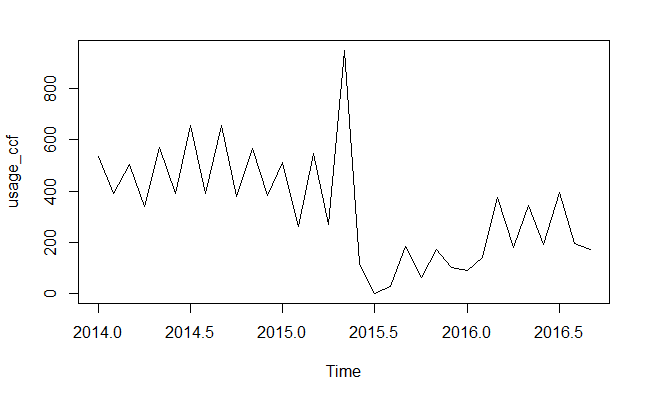

```r
plot.ts(smc_timeseries)
```

Moving average of second order

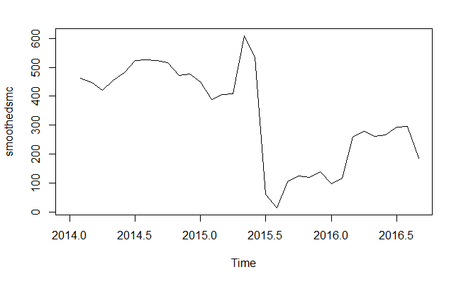

```r
smoothedsmc <- SMA(smc_timeseries,n=2)
plot.ts(smoothedsmc)
```

We can observe that there is a severe downfall at mid 2015

Here we can observe trend and seasonal components separately

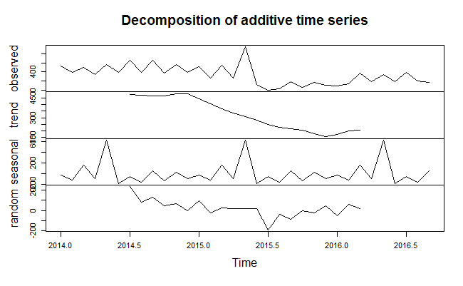

```r
smccomponents <- decompose(smc_timeseries)
plot(smccomponents)
```

Detach the seasonal component and see the plot

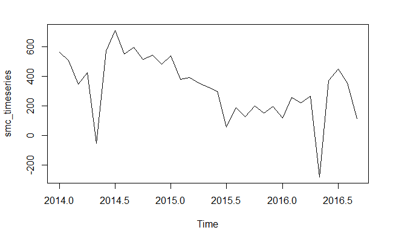

```r
smcseasonallyadjusted <- smc_timeseries - smccomponents$seasonal
plot(smcseasonallyadjusted)
```

Simple exponential smoothing for default ts assuming no trend. In plot, Red line is the forecast, Black line is the original data

```r
smc_notrend <- HoltWinters(smc_timeseries, beta=FALSE, gamma=FALSE)
smc_notrend
```

```
Holt-Winters exponential smoothing without trend and without seasonal component.

Call:
HoltWinters(x = smc_timeseries, beta = FALSE, gamma = FALSE)

Smoothing parameters:
 alpha: 0.2562956
 beta : FALSE
 gamma: FALSE

Coefficients:
      [,1]
a 230.3827
```

```r
smc_notrend$SSE
```

```
[1] 1216009
```

```r
smc_notrend$fitted
```

```
             xhat    level
Feb 2014 536.4960 536.4960
Mar 2014 499.0786 499.0786
Apr 2014 500.0857 500.0857
May 2014 459.1889 459.1889
Jun 2014 487.7726 487.7726
Jul 2014 463.1109 463.1109
Aug 2014 512.9863 512.9863
Sep 2014 482.0616 482.0616
Oct 2014 526.5754 526.5754
Nov 2014 488.3672 488.3672
Dec 2014 508.6866 508.6866
Jan 2015 477.0278 477.0278
Feb 2015 486.4349 486.4349
Mar 2015 428.9734 428.9734
Apr 2015 459.4643 459.4643
May 2015 411.0977 411.0977
Jun 2015 549.2380 549.2380
Jul 2015 439.0786 439.0786
Aug 2015 327.0344 327.0344
Sep 2015 250.0785 250.0785
Oct 2015 233.2261 233.2261
Nov 2015 189.8119 189.8119
Dec 2015 185.4931 185.4931
Jan 2016 164.2464 164.2464
Feb 2016 145.3109 145.3109
Mar 2016 144.2799 144.2799
Apr 2016 203.6974 203.6974
May 2016 197.8989 197.8989
Jun 2016 235.2225 235.2225
Jul 2016 223.7857 223.7857
Aug 2016 267.7989 267.7989
Sep 2016 249.5635 249.5635
```

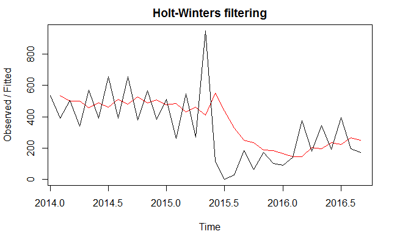

```r
plot(smc_notrend)
```

Simple exponential smoothing for seasonally adjusted ts assuming no trend - plotting seasonally adjusted data forecast gives us slightly better sum of squared errors

```r
smc_adjusted <- HoltWinters(smcseasonallyadjusted, beta=FALSE, gamma=FALSE)
smc_adjusted
```

```
Holt-Winters exponential smoothing without trend and without seasonal component.

Call:
HoltWinters(x = smcseasonallyadjusted, beta = FALSE, gamma = FALSE)

Smoothing parameters:
 alpha: 0.2935704
 beta : FALSE
 gamma: FALSE

Coefficients:
      [,1]
a 231.4983
```

```r
smc_adjusted$SSE
```

```
[1] 1165723
```

```r
smc_adjusted$fitted
```

```
              xhat     level
Feb 2014 564.10588 564.10588
Mar 2014 547.88757 547.88757
Apr 2014 488.91380 488.91380
May 2014 470.67652 470.67652
Jun 2014 317.27494 317.27494
Jul 2014 391.88323 391.88323
Aug 2014 485.99792 485.99792
Sep 2014 505.62658 505.62658
Oct 2014 532.73181 532.73181
Nov 2014 526.97222 526.97222
Dec 2014 532.43208 532.43208
Jan 2015 517.21316 517.21316
Feb 2015 524.29664 524.29664
Mar 2015 482.10945 482.10945
Apr 2015 455.63720 455.63720
May 2015 426.68742 426.68742
Jun 2015 397.57184 397.57184
Jul 2015 368.71948 368.71948
Aug 2015 277.11059 277.11059
Sep 2015 250.74656 250.74656
Oct 2015 214.28264 214.28264
Nov 2015 209.92842 209.92842
Dec 2015 192.59454 192.59454
Jan 2016 194.18826 194.18826
Feb 2016 171.81427 171.81427
Mar 2016 197.59901 197.59901
Apr 2016 204.20669 204.20669
May 2016 222.74296 222.74296
Jun 2016  75.43137  75.43137
Jul 2016 162.04480 162.04480
Aug 2016 246.65967 246.65967
Sep 2016 279.10599 279.10599
```

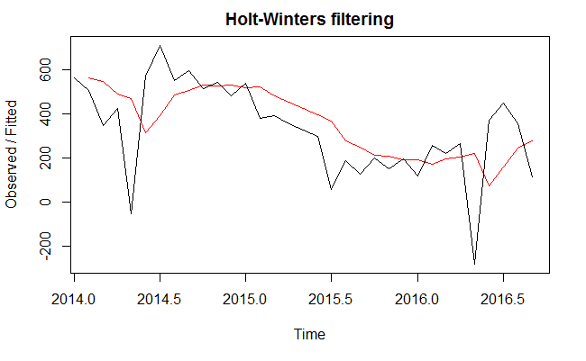

```r
plot(smc_adjusted)
```

Predicting for next 5 months

```r
smc_adjusted_forecasts <- forecast.HoltWinters(smc_adjusted, h=5)
smc_adjusted_forecasts
```

```
         Point Forecast     Lo 80    Hi 80     Lo 95    Hi 95
Oct 2016       231.4983 -12.70362 475.7002 -141.9763 604.9729
Nov 2016       231.4983 -23.00926 486.0059 -157.7374 620.7340
Dec 2016       231.4983 -32.91354 495.9101 -172.8847 635.8813
Jan 2017       231.4983 -42.45998 505.4566 -187.4847 650.4813
Feb 2017       231.4983 -51.68479 514.6814 -201.5929 664.5895
```

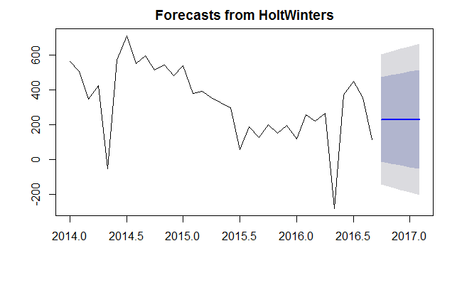

```r
plot.forecast(smc_adjusted_forecasts)
```

Lets see residuals(errors)

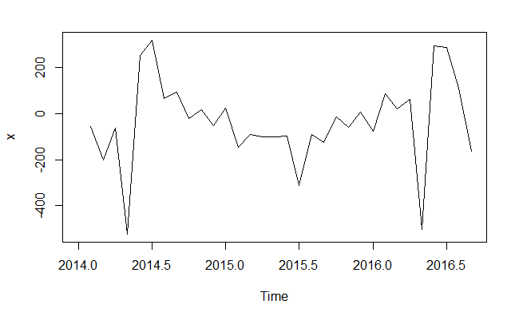

```r
plot(smc_adjusted_forecasts$residuals)
```

With acf and Ljung-Box tests, we can see that there are no non-zero auto correlations as the p value is very high

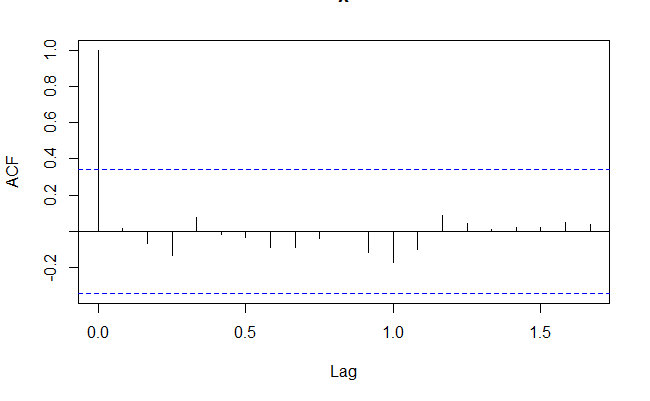

```r
acf(smc_adjusted_forecasts$residuals, lag.max = 20,na.action = na.pass)
```

```r
Box.test(smc_adjusted_forecasts$residuals, lag=20, type="Ljung-Box")
```

```
    Box-Ljung test

data:  smc_adjusted_forecasts$residuals
X-squared = 5.8327, df = 20, p-value = 0.9991
```

Function to check whether forecast errors are normally distributed with mean zero

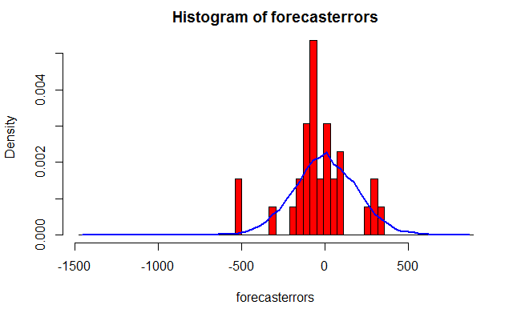

```r
plotForecastErrors <- function(forecasterrors)
{
  # make a histogram of the forecast errors:
  mybinsize <- IQR(forecasterrors,na.rm=TRUE)/4
  mysd   <- sd(forecasterrors,na.rm=TRUE)
  mymin  <- min(forecasterrors,na.rm=TRUE) - mysd*5
  mymax  <- max(forecasterrors,na.rm=TRUE) + mysd*3
  # generate normally distributed data with mean 0 and standard deviation mysd
  mynorm <- rnorm(10000, mean=0, sd=mysd)
  mymin2 <- min(mynorm)
  mymax2 <- max(mynorm)
  if (mymin2 < mymin) { mymin <- mymin2 }
  if (mymax2 > mymax) { mymax <- mymax2 }
  # make a red histogram of the forecast errors, with the normally distributed data overlaid:
  mybins <- seq(mymin, mymax, mybinsize)
  hist(forecasterrors, col="red", freq=FALSE, breaks=mybins)
  # freq=FALSE ensures the area under the histogram = 1
  # generate normally distributed data with mean 0 and standard deviation mysd
  myhist <- hist(mynorm, plot=FALSE, breaks=mybins)
  # plot the normal curve as a blue line on top of the histogram of forecast errors:
  points(myhist$mids, myhist$density, type="l", col="blue", lwd=2)
}
plotForecastErrors(smc_adjusted_forecasts$residuals)
```

The plot shows that the distribution of forecast errors is roughly centred on zero, and is more or less normally distributed. The Ljung-Box test showed that there is little evidence of non-zero autocorrelations in the in-sample forecast errors, and the distribution of forecast errors seems to be normally distributed with mean zero. This suggests that the simple exponential smoothing method provides an adequate predictive model for water usage. Furthermore, the assumptions that the 80% and 95% predictions intervals were based upon (that there are no autocorrelations in the forecast errors, and the forecast errors are normally distributed with mean zero and constant variance) are probably valid.

Holts exponential model(assuming there is a trend and no seasonality)

```r
smc_trend <- HoltWinters(smc_timeseries, gamma=FALSE)
smc_trend
```

```
Holt-Winters exponential smoothing with trend and without seasonal component.

Call:
HoltWinters(x = smc_timeseries, gamma = FALSE)

Smoothing parameters:
 alpha: 0.4445594
 beta : 0.3009736
 gamma: FALSE

Coefficients:
        [,1]
a 247.206318
b  -5.495393
```

```r
smc_trend$SSE
```

```
[1] 1700652
```

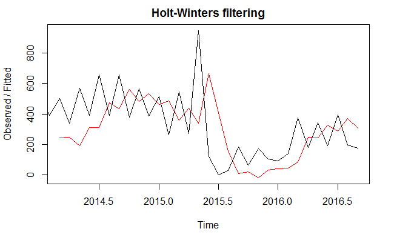

```r
plot(smc_trend)
```

Lets predict for the next 5 months

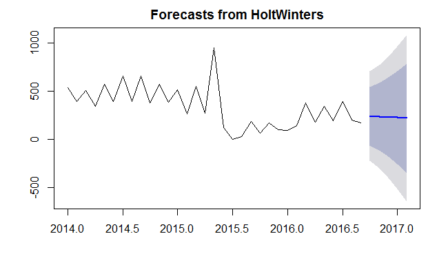

```r
smc_trend <- forecast.HoltWinters(smc_trend, h=5)
plot.forecast(smc_trend)
```

Lets check the residuals

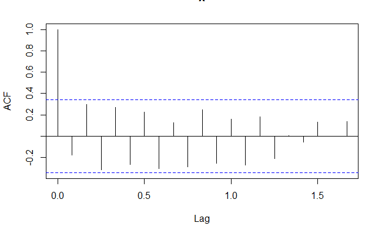

```r
acf(smc_trend$residuals, lag.max = 20,na.action = na.pass)
```

```r
Box.test(smc_trend$residuals, lag=20, type="Ljung-Box")
```

```
    Box-Ljung test

data:  smc_trend$residuals
X-squared = 43.882, df = 20, p-value = 0.001561
```

p-value is very low - indicates evidence of non-zero auto correlations. Model could be improved.

Lets check for constant variance and normal distribution with mean zero in residuals

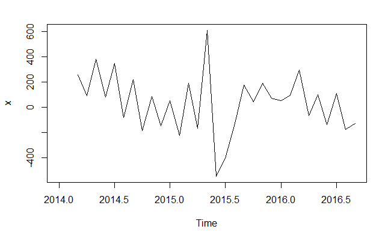

```r
plot.ts(smc_trend$residuals)            # make a time plot
```

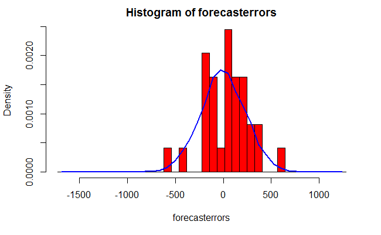

```r
plotForecastErrors(smc_trend$residuals) # make a histogram
```

```r
mean(smc_trend$residuals,na.rm=TRUE)
```

```
[1] 33.87264
```

If we observe carefully, mean is to the right of zero. This model shoud not be considered.

Holt-Winter’s Exponential smoothing (assuming there is trend and seasonality)

```r
smc_trend_seasonality <- HoltWinters(smc_timeseries)
smc_trend_seasonality$SSE
```

```
[1] 747350.6
```

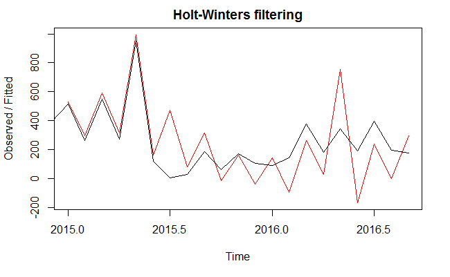

```r
plot(smc_trend_seasonality)
```

Predicting for the next 5 months

```r
smc_trend_seasonality <- forecast.HoltWinters(smc_trend_seasonality, h=5)
smc_trend_seasonality
```

```
         Point Forecast     Lo 80    Hi 80     Lo 95    Hi 95
Oct 2016      -29.17233 -276.9003 218.5556 -408.0395 349.6949
Nov 2016      129.27206 -125.8318 384.3759 -260.8757 519.4198
Dec 2016      -76.48897 -338.7614 185.7835 -477.6001 324.6221
Jan 2017       71.93817 -197.3121 341.1884 -339.8445 483.7209
Feb 2017     -155.80882 -431.8605 120.2429 -577.9935 266.3758
```

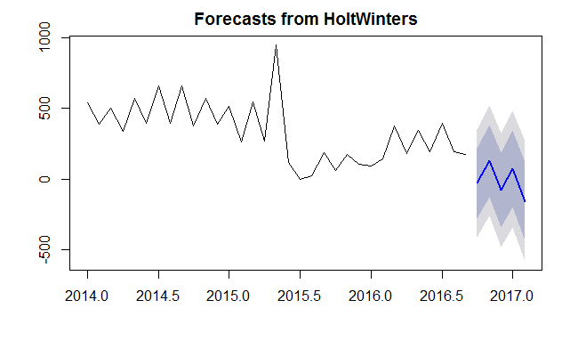

```r
plot(smc_trend_seasonality)
```

Checking Residuals

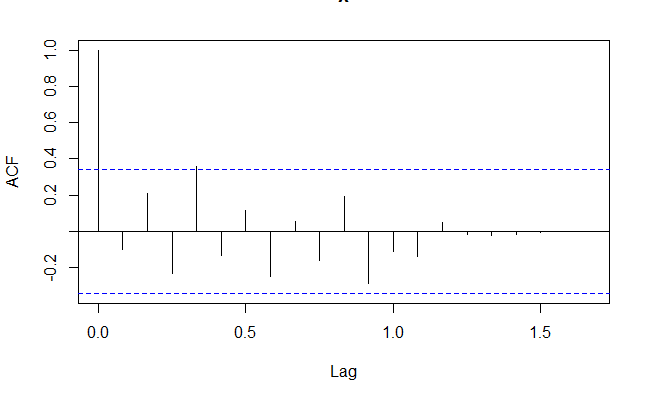

```r
acf(smc_trend_seasonality$residuals, lag.max=20,na.action = na.pass)
```

```r
Box.test(smc_trend_seasonality$residuals, lag=20, type="Ljung-Box")
```

```
    Box-Ljung test

data:  smc_trend_seasonality$residuals
X-squared = 18.524, df = 20, p-value = 0.5529
```

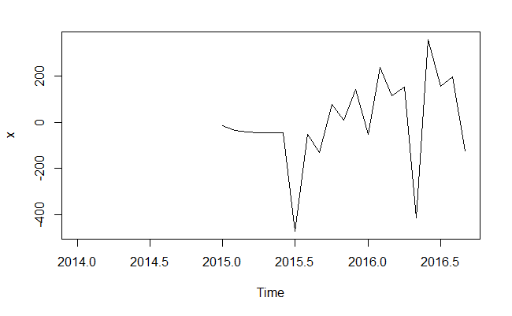

```r
plot.ts(smc_trend_seasonality$residuals)            # make a time plot
```

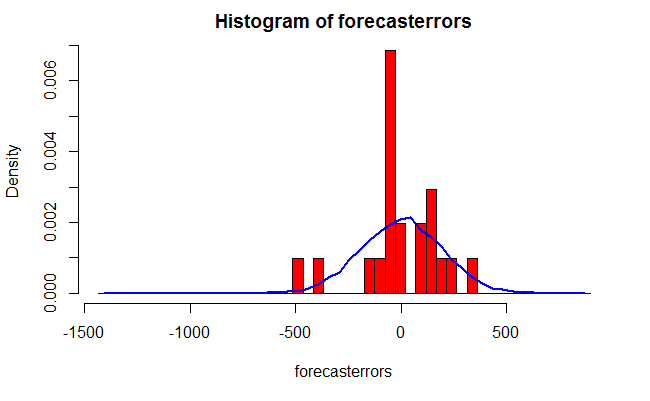

```r
plotForecastErrors(smc_trend_seasonality$residuals) # make a histogram
```

p-value is high and residuals are normally distributed with mean 0 - residuals are independent

# ARIMA Model

ARIMA allows for non-zero auto correlations to exist

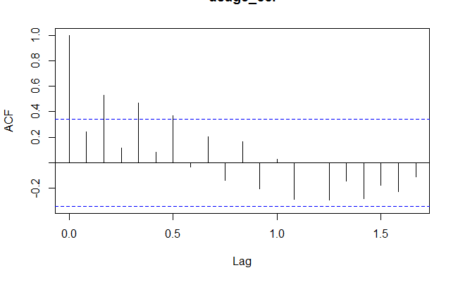

```r
acf(smc_timeseries, lag.max=20)             # plot a correlogram
```

```r
acf(smc_timeseries, lag.max=20, plot=FALSE) # get the autocorrelation values
```

```
Autocorrelations of series â€˜smc_timeseriesâ€™, by lag

0.0000 0.0833 0.1667 0.2500 0.3333 0.4167 0.5000 0.5833 0.6667 0.7500 0.8333 0.9167 1.0000 1.0833 1.1667 1.2500 1.3333 1.4167 1.5000
 1.000  0.240  0.526  0.114  0.467  0.085  0.366 -0.032  0.204 -0.139  0.166 -0.206  0.026 -0.286  0.002 -0.294 -0.143 -0.284 -0.178
1.5833 1.6667
-0.228 -0.110
```

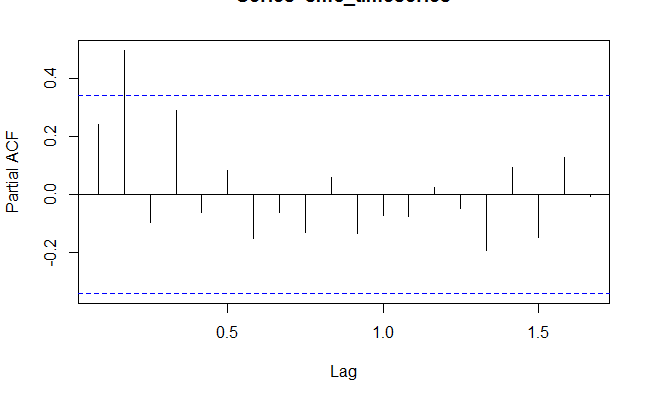

```r
pacf(smc_timeseries, lag.max=20)
```

```r
pacf(smc_timeseries, lag.max=20, plot=FALSE) #get partial autocorrelation values
```

```
Partial autocorrelations of series â€˜smc_timeseriesâ€™, by lag

0.0833 0.1667 0.2500 0.3333 0.4167 0.5000 0.5833 0.6667 0.7500 0.8333 0.9167 1.0000 1.0833 1.1667 1.2500 1.3333 1.4167 1.5000 1.5833
 0.240  0.497 -0.097  0.289 -0.064  0.084 -0.151 -0.063 -0.133  0.058 -0.134 -0.073 -0.075  0.024 -0.048 -0.195  0.093 -0.147  0.128
1.6667
-0.008
```

We can select a model(p,d,q) based on the above information or go with a nice function auto.arima() to select optimal model

Passing original timeseries without any adjustments or differences. Auto Arima takes care of differences and selects optimal model

```r
smctrain <- auto.arima(smc_ts_matrix, trace = TRUE)
```

```
 ARIMA(2,1,2) with drift         : Inf
 ARIMA(0,1,0) with drift         : 451.4597
 ARIMA(1,1,0) with drift         : 433.0462
 ARIMA(0,1,1) with drift         : Inf
 ARIMA(0,1,0)                    : 449.2391
 ARIMA(2,1,0) with drift         : 435.6649
 ARIMA(1,1,1) with drift         : 435.3071
 ARIMA(2,1,1) with drift         : Inf
 ARIMA(1,1,0)                    : 430.8259
 ARIMA(2,1,0)                    : 433.2664
 ARIMA(1,1,1)                    : 433.0409
 ARIMA(2,1,1)                    : 433.9095

 Best model: ARIMA(1,1,0)
```

```r
smctrain
```

```
Series: smc_ts_matrix
ARIMA(1,1,0)

Coefficients:
          ar1
      -0.6806
s.e.   0.1226

sigma^2 estimated as 36309:  log likelihood=-213.21
AIC=430.41   AICc=430.83   BIC=433.34
```

Prediction

```r
smcprediction <- forecast.Arima(smctrain, h=5)
smcprediction
```

```
   Point Forecast      Lo 80    Hi 80     Lo 95    Hi 95
34       189.6463  -54.55090 433.8436 -183.8211 563.1138
35       179.4910  -76.86038 435.8423 -212.5646 571.5465
36       186.4026 -133.34706 506.1523 -302.6123 675.4176
37       181.6986 -157.80836 521.2056 -337.5325 700.9297
38       184.9001 -193.24641 563.0467 -393.4251 763.2254
```

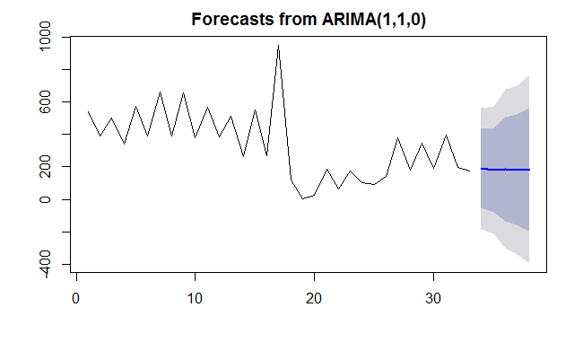

```r
plot.forecast(smcprediction)
```

Checking residuals

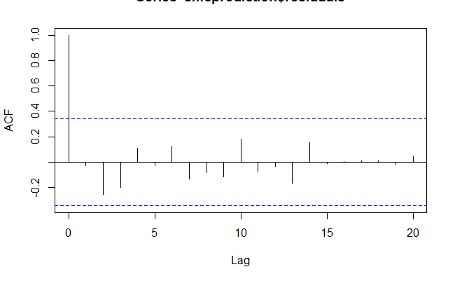

```r
acf(smcprediction$residuals, lag.max=20)
```

```r
Box.test(smcprediction$residuals, lag=20, type="Ljung-Box")
```

```
    Box-Ljung test

data:  smcprediction$residuals
X-squared = 12.222, df = 20, p-value = 0.9082
```

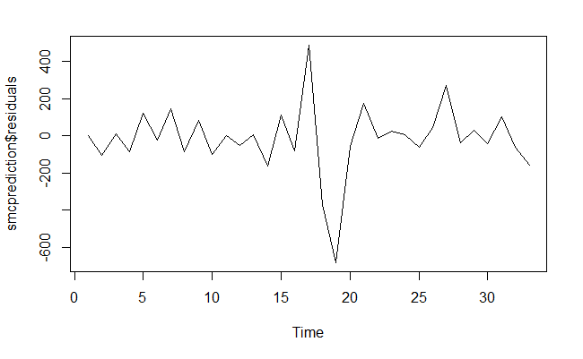

```r
plot.ts(smcprediction$residuals)            # make time plot of forecast errors
```

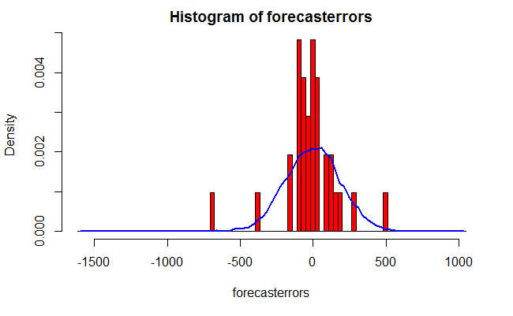

```r
plotForecastErrors(smcprediction$residuals) # make a histogram
```

```r
mean(smcprediction$residuals)
```

```
[1] -16.77279
```

The successive forecast errors do not seem to be correlated, but the forecast errors do not seem to be normally distributed with mean zero and constant variance, the ARIMA(1,1,0) does not seem to be an adequate predictive model for the water usage and could be improved. This time series is too random to predict and might need fourier series transformation.